# MEDB 5501, Module08

2025-10-14

## Topics to be covered

- What you will learn
  - The two-sample t-test
  - The t-distribution
  - Critical values and p-values
  - R code for the t-test
  - Confidence intervals
  - Sample size justification
  - R code for sample size justification
  - Your homework

## Population model

- Population 1
  - $X_{11},X_{12},...,X_{1N_1}$
  - $X_{1i}$ are independent $N(\mu_1,\sigma_1)$
- Population 2
  - $X_{21},X_{22},...,X_{2N_2}$
  - $X_{2i}$ are independent $N(\mu_2,\sigma_2)$

## Sample values

- Sample 1
  - $X_{11},X_{12},...,X_{1n_1}$
  - Calculate $\bar{X}_1$ and $S_1$
- Sample 2
  - $X_{21},X_{22},...,X_{2n_2}$
  - Calculate $\bar{X}_2$ and $S_2$

## Hypothesis and test statistic

- $H_0:\ \mu_1 - \mu_2 = 0$
- $H_1:\ \mu_1 - \mu_2 \ne 0$
  - Accept $H_0$ if $\bar{X}_1-\bar{X}_2$ is close to zero

## How close is close?

- $T = \frac{\bar{X}_1-\bar{X}_2}{se}$
- se = standard error
  - $se = S_p \sqrt{\frac{1}{n_1}+\frac{1}{n_2}}$
- $S_p$ = Pooled standard deviation - $S_p = \sqrt{\frac{n_1\ S_1^2\ +\ n_2\ S_2^2}{n_1\ +\ n_2}}$
- Not valid with heterogeneity
  - That is, $\sigma_1 \ne \sigma_2$

## Break #1

- What you have learned
  - The two-sample t-test
- What’s coming next
  - The t-distribution

## The t distribution

- $T=\frac{\bar{X}_1-\bar{X}_2}{se}$
  - Variation in the numerator AND the denominator
  - Use a t-distribution, not a normal distribution
    - $df=n_1+n_2-2$

## Comparing the t and normal distributions

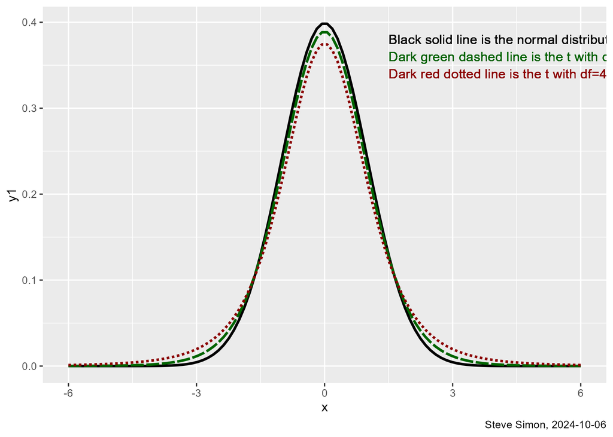

## P[t(4) < 1.5]

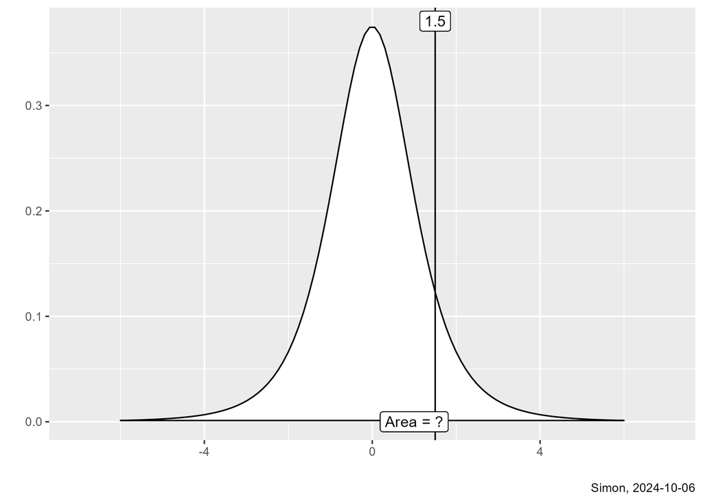

```r
pt(1.5, 4)
```

```
[1] 0.896
```

```r
#
# Compare this
# to the normal
# probability
#
pnorm(1.5)
```

```
[1] 0.9331928
```

## P[t(4) > 1]

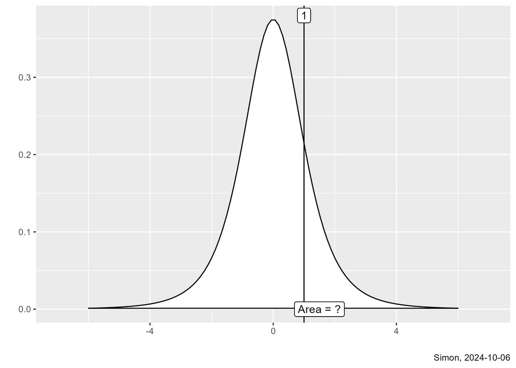

```r
1-pt(1, 4)
```

```
[1] 0.1869505
```

## P[-2.5 < t(4) < 2.5]

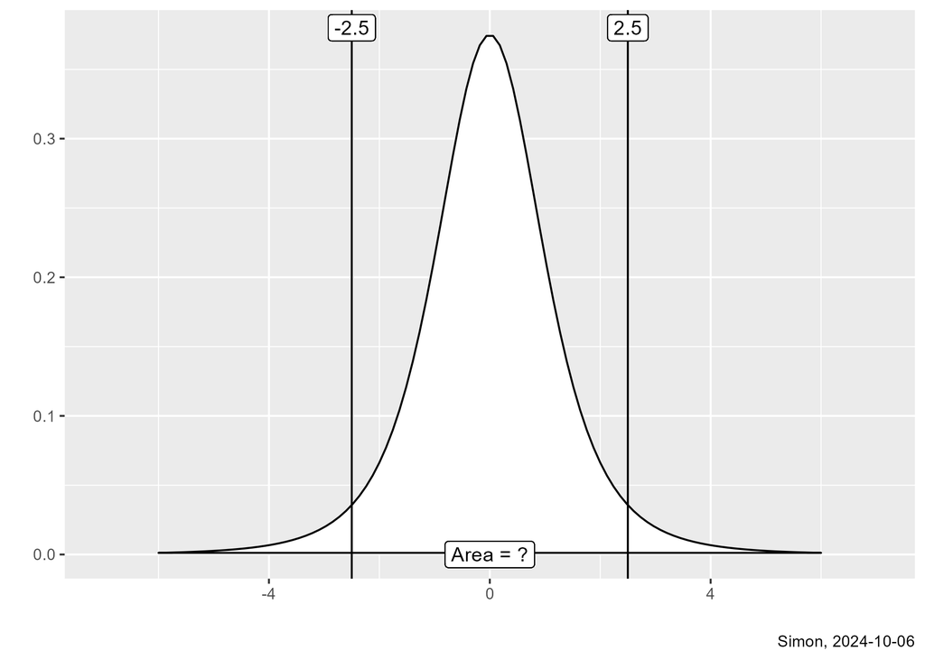

```r
pt(2.5, 4)-pt(-2.5, 4)
```

```
[1] 0.9332335
```

## 25th percentile of t(4)

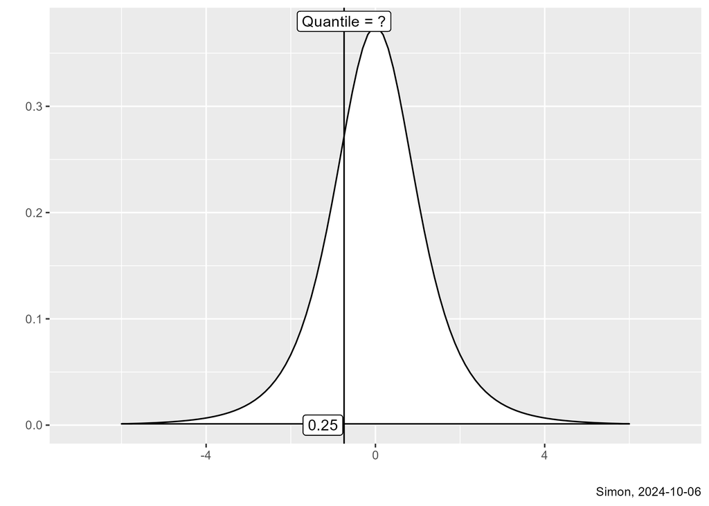

```r
qt(0.25, 4)
```

```
[1] -0.7406971
```

## Break #2

- What you have learned
  - The t-distribution
- What’s coming next
  - Critical values and p-values

## Type I and Type II errors

- Type I error, Rejecting the null hypothesis when the null hypothesis is true
  - $\alpha$ is the probability of a Type I error
- Type II error, Accepting the null hypothesis when the null hypothesis is false
  - $\beta$ is the probability of a Type II error
  - Power = 1 - $\beta$

## Critical values, 1

- $H_0:\ \mu_1 - \mu_2 = 0$
- $H_1:\ \mu_1 - \mu_2 \ne 0$
  - $T=\frac{\bar{X}_1-\bar{X}_2}{se}$
  - Accept $H_0$ if $t(\alpha/2, df) < T < t(1-\alpha/2, df)$

## Critical values, 2

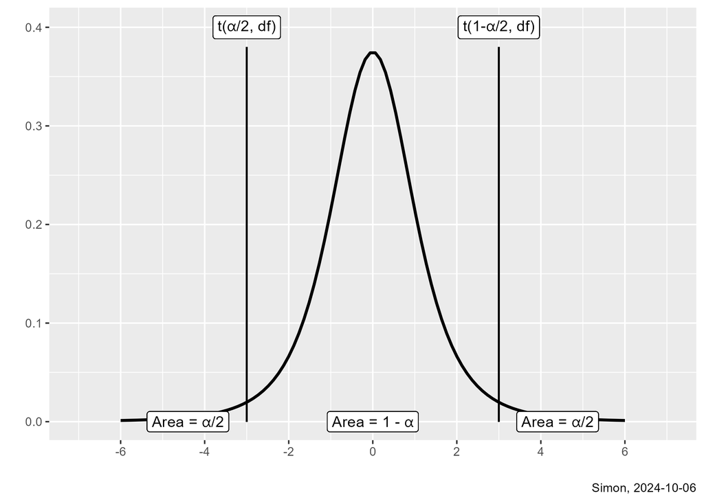

## Critical values, 3

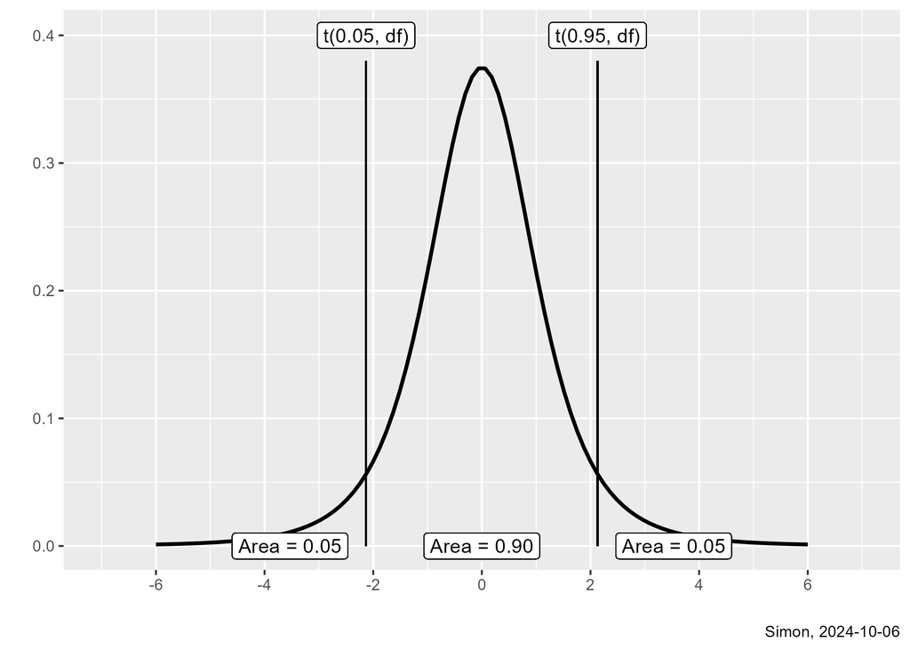

## Critical values, 4

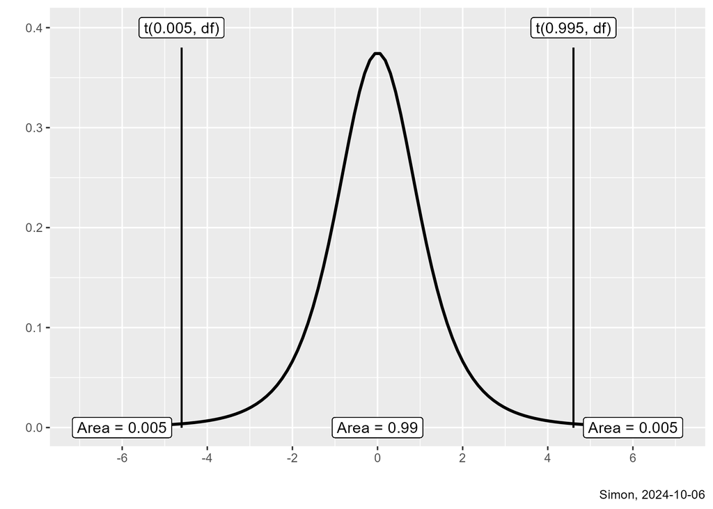

## Critical values, 5

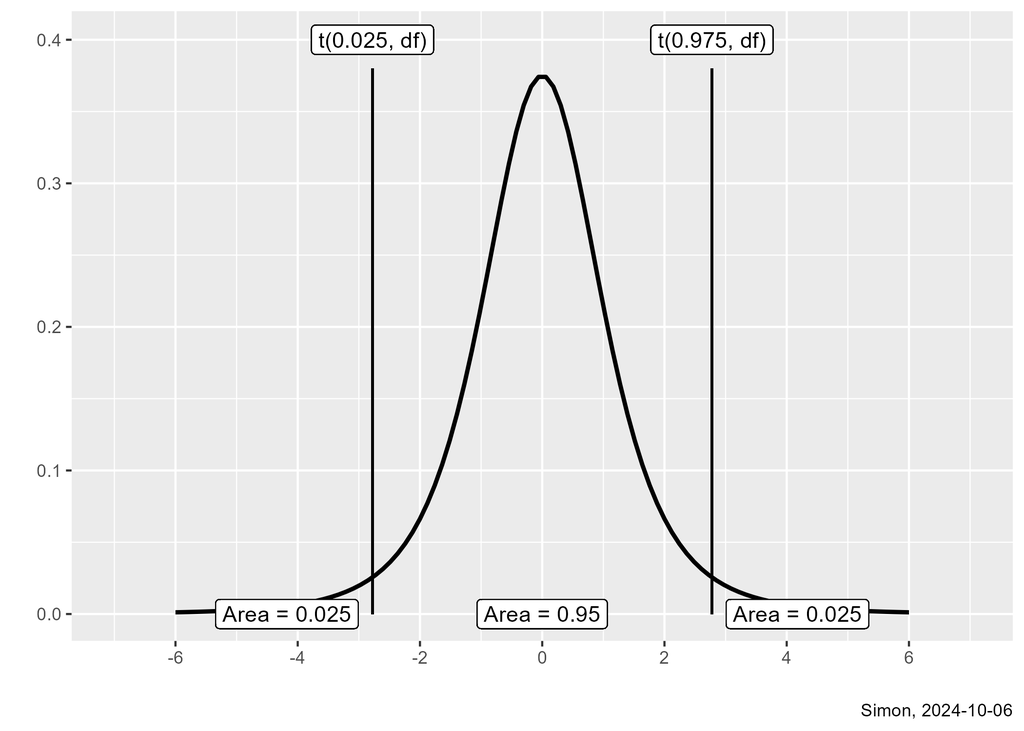

## Which critical values should you choose?

- If a Type I error is far more serious than a Type II error,
  - Use t(0.005, df) and t(0.995)
  - P[Type I error] = 0.01 (conservative)
- If a Type II error is far more serious than a Type I error,
  - Use t(0.05, df) and t(0.95)
  - P[Type I error] = 0.10 (liberal)
- If you want to avoid controversy
  - Use t(0.025, df) and t(0.975)
  - P[Type I error] = 0.05
  - Lemming school of research

## P-value

- p-value = $2 P[t(n_1+n_2-2) > |T|]$
  - Probability of sample results or results more extreme
  - Accept $H_0$ if p-value > $\alpha$
- Why the 2?
  - Measuring extremity in either direction

## Postural sway data, 1

```
# A tibble: 2 × 4
  Age     fb_mn fb_sd     n
  <chr>   <dbl> <dbl> <int>
1 Elderly  26.3  9.77     9
2 Young    18.1  4.09     8
```

## Postural sway data, 2

- Calculate pooled standard deviation
  - $S_p$ = $\sqrt{\frac{n_1\ S_1^2\ +\ n_2\ S_2^2}{n_1\ +\ n_2}}$
  - $S_p$ =$\sqrt{\frac{9\ (9.77)^2\ +\ 8\ (4.09)^2}{9\ +\ 8}}$
  - $S_p$ = 7.64

## Postural sway data, 3

- Calculate standard error
  - se = $S_p \sqrt{\frac{1}{n_1}+\frac{1}{n_2}}$
  - se = $7.64 \sqrt{\frac{1}{9}+\frac{1}{8}}$
  - se = 3.71

## Postural sway data, 4

- Calculate T
  - T = $\frac{\bar{X}_1-\bar{X}_2}{se}$
  - T = $\frac{26.3-18.1}{3.72}$
  - T = 2.2

## Postural sway data, 5

- Calculate degrees of freedom
  - df = n1 + n2 - 2
- Calculate critical values
  - t(0.025, 15) = qt(0.025, 15) = -2.13
  - t(0.975, 15) = qt(0.975, 15) = 2.13
  - Since T is outside the two critical values, reject $H_0$

## Postural sway data, 6

- Calculate p-value
  - p.value = $P[t(n_1+n_2-2) > |T|]$
  - p.value = $2\ P[t(15) > |2.2|]$ = 2*(1-pt(2.2, 15)) = 0.044

## Postural sway data, 7

```
    Two Sample t-test

data:  FBSway by Age
t = 2.2044, df = 15, p-value = 0.04353
alternative hypothesis: true difference in means between group Elderly and group Young is not equal to 0
95 percent confidence interval:
  0.2715453 16.1451214
sample estimates:
mean in group Elderly   mean in group Young
             26.33333              18.12500
```

## A proper interpretation

- $H_0:\ \mu_1 - \mu_2 = 0$
- $H_1:\ \mu_1 - \mu_2 \ne 0$
  - Reject the null hypothesis and conclude that the mean front-to-back sway in the population of elderly patients is greater than the mean front-to-back sway in the population of young patients.
- What to look for in the interpretation
  - A statement about the population, not the sample
  - Use of directional words

## Break #3

- What you have learned
  - Critical values and p-values
- What’s coming next
  - R code for the t-test

## Confidence interval for difference in means

- $\bar{X}_1-\bar{X}_2 \pm t(1-\alpha/2, n_1+n_2-2) se$
  - Range of plausible values for $\mu_1-\mu_2$

## Interpretation

- Statement about population mean difference ($\mu_1-\mu_2$)
- Range of plausible values
- Not a probability statement
  - 95% confidence does not mean 95% probability
- If you collected 100 independent samples,
  - Roughly 95 would contain $\mu_1-\mu_2$

## Using a confidence interval to test a hypothesis

- A confidence interval is a statement about $\mu_1-\mu_2$
  - Accept $H_0$ if interval contains zero
  - Reject $H+0$ if interval does not contain zero

## Example with the postural sway data

```
    Two Sample t-test

data:  FBSway by Age
t = 2.2044, df = 15, p-value = 0.04353
alternative hypothesis: true difference in means between group Elderly and group Young is not equal to 0
95 percent confidence interval:
  0.2715453 16.1451214
sample estimates:
mean in group Elderly   mean in group Young
             26.33333              18.12500
```

## Break #5

- What you have learned
  - Confidence intervals
- What’s coming next
  - Sample size justification

## Three things you need to justify your sample size

1. Research hypothesis
2. Measure of variability
3. Minimum clinically important difference (MCID)

## Scenario

- Replicate postural sway study
  - Different populations
  - Same outcome measure
- Research hypothesis, $H_0\ \mu_1 - \mu_2 = 0$
- Standard deviations: 9.77, 4.09
- MCID = 4

## Scenario, R code

```r
sample_size_estimate <- power.t.test(
  n=NULL,
  delta=4,
  sd=9.8,
  sig.level=0.05,
  power=0.9,
  type="two.sample",
  alternative="two.sided")
```

## Scenario, Output

```
     Two-sample t test power calculation

              n = 127.1097
          delta = 4
             sd = 9.8
      sig.level = 0.05
          power = 0.9
    alternative = two.sided

NOTE: n is number in *each* group
```

## Break #6

- What you have learned
  - Sample size justification
- What’s coming next
  - R code for sample size justification

## Live demo

This will be a live demonstration of part 2 of simon-5501-08-demo.

## Break #7

- What you have learned
  - R code for sample size justification
- What’s coming next
  - Your homework

## simon-5501-08-directions.md

Refer to the [programming assignment](https://github.com/pmean/classes/blob/master/biostats-1/08/src/simon-5501-08-directions.md) on my github site.

## Summary

- What you have learned
  - The two-sample t-test
  - The t-distribution
  - Critical values and p-values
  - R code for the t-test
  - Confidence intervals
  - Sample size justification
  - R code for sample size justification
  - Your homework